# A short introduction to the SIMEX and MCSIMEX

Abstract

“A short introduction to the SIMEX and MCSIMEX” published in R News.

In statistical practice variables are often contaminated with measurement error. This may be the case due to bad measurement tools or because the true variable can not be measured directly. In the case of discrete variables, measurement error is referred to as misclassification. In the framework of general regression, measurement error or misclassification can lead to serious bias in the estimated parameters. In most cases the estimated effect of the contaminated variable is attenuated, e.g., see Carroll et al. (2006).

Among other methods the simulation and extrapolation method (SIMEX) by Cook and Stefanski (1994) has become a useful tool for correcting effect estimates in the presences of additive measurement error. The method is especially helpful for complex models with a simple measurement error structure. The same basic idea of simulation and extrapolation has been transferred to the case of misclassification (MC-SIMEX) by Küchenhoff et al. (2006).

The R package **simex** provides functions to use the SIMEX or MC-SIMEX methods for various kinds of regression objects and to produce graphics and summary statistics for corrected objects. There are also functions to provide help in constructing misclassification matrices.

## Theory

We want to estimate an effect parameter (vector) $\beta$ in a general regression model in the presence of misclassification or measurement error. We assume that an estimator, which is consistent when all variables are measured without error, is available. This estimator is called the naive estimator when it is used although there is measurement error in the data. The SIMEX-method uses the relationship between the size of the measurement error, described by the measurement error variance $\sigma_u^2$ and the bias of the effect estimator when ignoring the measurement error. So we can define the function

$$\sigma_u^2 \longrightarrow
\beta^*(\sigma_u^2) := \mathcal{G}(\sigma_u^2)$$

where $\beta^*$ is the limit to which the naive estimator converges as the sample size $n \to \infty$. Consistency implies that $\mathcal{G}(0) = \beta$. The idea of the SIMEX method is to approximate the function $\mathcal{G}(\sigma_u^2)$ by a parametric approach $\mathcal{G}(\sigma^2, \Gamma)$, for example with a quadratic approximation $\mathcal{G}_{quad}(\sigma_u^2, \Gamma) = \gamma_0 + \gamma_1 \sigma_u^2 + \gamma_2 (\sigma_u^2)^2$.

In the simulation step, to estimate $\Gamma$, the method adds measurement error with variance $\lambda \sigma_u^2$ to the contaminated variable, where $\lambda > 0$ quantifies the additional amount of measurement error that is added. The resulting measurement error variance is then $(1 + \lambda)\sigma_u^2$. The naive estimator for this increased measurement error is calculated. This simulation procedure is repeated $B$ times. The average over the $B$ estimators estimates $\mathcal{G}((1 + \lambda)\sigma_u^2)$. Performing these simulations for a fixed grid of $\lambda$s, leads to an estimator for $\hat{\Gamma}$ of the parameters $\mathcal{G}(\sigma_u^2, \Gamma)$, for example by least squares. Simulation results indicate that $\lambda \in (0.5, 1, 1.5, 2)$ is a good choice in most cases.

In the extrapolation step the approximated function $\mathcal{G}(\sigma_u^2, \hat{\Gamma})$ is extrapolated back to the case of no measurement error and so the SIMEX estimator is defined by $\hat{\beta}_{simex} := \mathcal{G}(0, \hat{\Gamma})$, which corresponds to $\lambda = -1$.

The misclassification error can be described by the misclassification matrix $\Pi$ which is defined via its components

$$\pi_{ij} = P(X^* = i \mid X =
j)$$

where $X^*$ is the misclassified version of $X$. $\Pi$ is a $k \times k$ matrix where $k$ is the number of possible outcomes of $X$. The estimator $\beta^*$ depends on the amount of misclassification and is defined by

$$\lambda \longrightarrow
\beta^*\left(\Pi^\lambda\right)$$

where $\Pi^\lambda$ is defined via its spectral decomposition $\Pi^\lambda := E\Lambda^\lambda E^{-1}$, with $\Lambda$ being the diagonal matrix of eigenvalues and $E$ the corresponding matrix of eigenvectors. This allows the SIMEX method to be applied to misclassification problems. The MCSIMEX estimator is then defined by the parametric approximation of the function

$$\lambda \to
\beta^*\left(\Pi^\lambda\right) \approx \mathcal{G}_\Pi(1 + \lambda,
\Gamma).$$

In the simulation step we simulate $B$ new pseudo data sets for a fixed grid of $\lambda$ by the misclassification operation defined by

$$X_i^* :=
\mathrm{MC}\left[\Pi^\lambda\right](X_i).$$

The misclassification operation $\mathrm{MC}[M](X_i)$ generates by simulation a misclassified version of the true, but unknown, variable $X_i$ denoted by $X_i^*$ which is related to $X_i$ by the misclassification matrix $M$. For each of these $B$ pseudo data sets the naive estimators are calculated and averaged for each $\lambda$. These averaged naive estimators converge to $\mathcal{G}_\Pi(1 + \lambda, \Gamma)$ and the estimation of $\Gamma$ via, e.g., least squares and so an approximation of $\mathcal{G}_\Pi(1 + \lambda, \Gamma)$ is feasible.

The MCSIMEX estimator is then defined by

$$\beta_{\mathrm{MCSIMEX}} :=
\mathcal{G}(0, \hat{\Gamma})$$

which corresponds again to $\lambda = -1$. One requirement for the application of the (MC-)SIMEX Method is that the measurement error variance or the misclassification matrix, respectively, has to be known or can be estimated by additional validation information.

## Variance estimation

The ease of getting corrected parameter estimates is somewhat offset by the complexity of the calculation of the parameter’s standard error. With its simulation character it is a natural candidate for the bootstrap. Although this is a valid method for obtaining standard errors, it is rather time consuming and for complex models not feasible. We implemented two other methods for the estimation of standard errors which have a smaller computational burden. The jackknife method was developed for the SIMEX method by Stefanski and Cook (1995). For the MCSIMEX method, it lacks theoretical foundation but simulation results indicate valid estimates for the standard errors.

An asymptotic approach based on estimation equations was developed by Carroll et al. (1996) for the SIMEX method and extended to the MCSIMEX method by Küchenhoff et al. (2006). It is possible to take the uncertainty of an estimated misclassification matrix or an estimated measurement error variance into account.

### Example

To illustrate the application of the `simex` package, we use a data set of a study about chronic bronchitis and dust concentration of the Deutsche Forschungsgemeinschaft (German research foundation). The data were recorded during the years 1960 and 1977 in a Munich plant (1246 workers). The data can be downloaded from http://www.stat.uni-muenchen.de/service/datenarchiv/dust/dust_e.html.

The data set contains 4 variables described in Table 1, and is read into the `data.frame` `dat` via the `read.table` command.

The naive model is then given by where *cbr* and *smoking* must be factors. The options ‘x’,‘y’ save the information about the response and the variables in the glm object and must be enabled for asymptotic variance estimation.

| *cbr* | Chronic Bronchitis Reaction | 1 : Yes 0 : No |
| --- | --- | --- |
| *dust* | Dust concentration at work | (in mg / m<sup>3</sup>) |
| *smoking* | Does worker smoke? | 1 : Yes 0 : No |
| *expo* | Duration of exposure | in years |

Table 1: Description of variables in the bronchitis data set.

```
> naive <- glm(cbr ~ dust + smoking + expo,
+             family= binomial,
+             data =dat, x=TRUE, y=TRUE)
```

## Continuous data

It is possible, that the variable *dust* is subject to measurement error. Because it is a continuous variable the SIMEX-method is to be used here. Usually the measurement error variance is estimated by replication or by a validation study, see Carroll et al. (2006), which is not available in this case. For illustration we assume that the additive measurement error has a standard deviation $\sigma = 2$. The estimation by the *simex* function is done as follows.

```
> mod.sim <- simex(naive,
+                 measurement.error = 2,
+                 SIMEXvariable="dust",
+                 fitting.method ="quad")
> mod.sim
```

Naive model:

```
glm(formula = cbr ~ dust + smoking + expo,
      family = binomial,
      data = dat, x = TRUE, y = TRUE)
```

SIMEX-Variables: dust  
Number of Simulations: 100

Coefficients:

| (Intercept) | dust | smoking1 | expo |
| --- | --- | --- | --- |
| -3.16698 | 0.13549 | 0.67842 | 0.03969 |

The default extrapolation function (“fitting.method”) for the function *simex* is a quadratic polynomial, which has a good performance in many cases. Other possibilities are a linear, a loglinear and a nonlinear extrapolation function. Unfortunately, the nonlinear extrapolation is numerically not stable and it is therefore advised to use it via the *refit* function. The *refit* function fits a new extrapolation function to the data obtained by the simulation step and yields therefore different estimators. It can be applied to objects of class MCSIMEX as well.

```
> refit(mod.sim, "nonl")
```

Naive model:

```
glm(formula = cbr ~ dust + smoking + expo,
      family = binomial,
      data = dat, x = TRUE, y = TRUE)
```

SIMEX-Variables: dust  
Number of Simulations: 100

Coefficients:

| (Intercept) | dust | smoking1 | expo |
| --- | --- | --- | --- |
| -3.33167 | 0.18904 | 0.67854 | 0.03956 |

```
> coef(naive)
(Intercept)      dust      smoking1      expo
-3.04787    0.09189      0.67684    0.04015
```

As can be seen from the displayed naive estimates, there is nearly no measurement error correction for the estimates of the *Intercept*, *smoking* and *expo*, while the corrected estimate for the variable *dust* differs substantially form the naive estimator. A comparison of both extrapolation functions for the last estimator is shown in Figure 1. Since the theory does not provide an optimal choice for the extrapolation function, different choices should be calculated and inspected graphically.

## Discrete Data

It is known that some participants do not tell the truth, when asked about their smoking behavior. Research from other studies indicates, that about 8% of smokers self-report them as non-smokers. So we use the misclassification matrix for smoking defined by and so the MCSIMEX-Algorithm can be used by calling the function *mcsimex()* and a quick overview can be obtained using the print method.

```
> mc.s <- matrix(c(1,0,0.08,0.92),nrow=2)
> dimnames(mc.s) <- list(levels(dat$smoking),
+                        levels(dat$smoking))
> mc.s
   0    1
0 1 0.08
1 0 0.92
```

```
>mod.smoking <- mcsimex(naive,
+                     mc.matrix = mc.s,
+                     SIMEXvariable = "smoking")
> mod.smoking
```

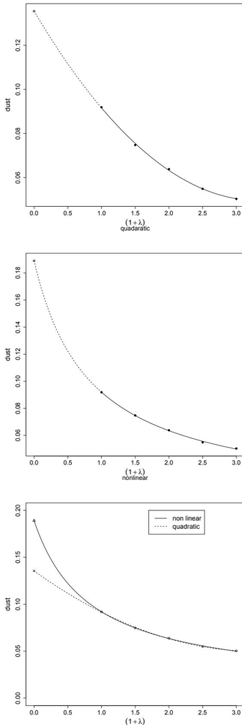

Figure 1: The effects of measurement error in variable dust produced with plot(mod.sim,ask = c(FALSE,TRUE,FALSE,FALSE)) and plot(refit(mod.sim,“nonl”),ask = c(FALSE,TRUE,FALSE,FALSE)) and combined in one diagram. Note that the point relating to \(1 + \lambda = 1\) corresponds to the naive estimate.

```
Naive model:
glm(formula = cbr ~ dust + smoking + expo,
      family = binomial, data = dat,
      x = TRUE, y = TRUE)
```

```
SIMEX-Variables: smoking
Number of Simulations: 100
```

```
Coefficients:
(Intercept)      dust        smoking1        expo
   -3.25827   0.09269         0.88086     0.04026
```

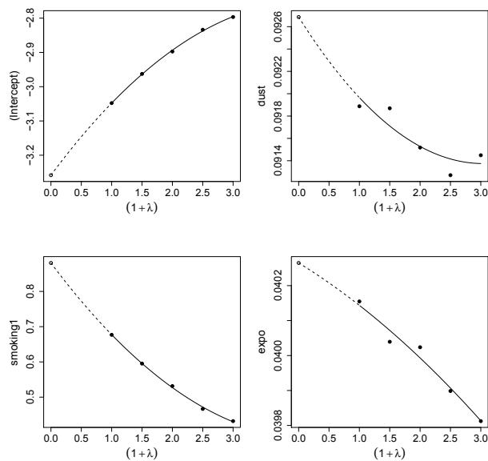

Figure 2: The effects of misclassification of smoking produced with plot(mod.smoking,mfrow = c(2,2)) .

More detailed information is available through the *summary* method, as shown in Figure 3 and the *plot* method which is shown in Figure 2. Notice that the correction of the effect estimates *intercept*, *dust* and *expo* are rather small in absolute value, but that *smoking* is corrected rather strongly.

Misclassification might as well occur in the response *cbr*. It is possible to correct for just the response or for both. In the following the code for correction of the response *cbr* and the variable *smoking* is shown. For illustration we assume that the misclassification probabilities are:  
$P(CBR_{\text{Obervered}} = 1 | CBR_{\text{true}} = 0) = 0.2$ and  
$P(CBR_{\text{Obervered}} = 0 | CBR_{\text{true}} = 1) = 0.1$.

```
> mc.cbr <- matrix(c(0.8,0.2,0.1,0.9),nrow=2)
> dimnames(mc.cbr) <- list(levels(dat$cbr),
+                          levels(dat$cbr))
> mc.cbr
    0   1
0 0.8 0.1
1 0.2 0.9
```

```
> mod.both <- mcsimex(naive,
+   mc.matrix =
+     list(smoking = mc.s, cbr = mc.cbr),
+   SIMEXvariable = c("cbr", "smoking"))
> mod.both
```

```
Naive model:
glm(formula = cbr ~ dust + smoking + expo,
      family = binomial,
      data = dat, x = TRUE, y = TRUE)
```

```
SIMEX-Variables: cbr, smoking
Number of Simulations: 100
```

```
Coefficients:
(Intercept)      dust        smoking1        expo
   -5.58519   0.16081         1.36969     0.07154
```

It is possible to model more complex kinds of misclassification, e.g., dependent misclassification, by submitting the name of a function that returns the misclassified variables, instead of a misclassification matrix to the function `mcsimex` . Although the SIMEX method could also be applied to situations where one variable is misclassified and another variable has additive measurement error, this is not implemented in our package.

## Summary

The package **simex** features easy to use functions for correcting estimation in regression models with measurement error or misclassification via the SIMEX– or MCSIMEX–method. It provides fast and easy means to produce plots that illustrate the effect of measurement error or misclassification on parameters. Several additional functions are available that help with various problems concerning misclassification or measurement error.

## References

- R. J. Carroll, D. Ruppert, L. A. Stefanski and C. Crainiceanu. *Measurement Error in Nonlinear Models: A Modern Perspektive, Second Edition*. Chapman and Hall, CRC press, 2006.
- R. J. Carroll, H. Küchenhoff, F. Lombard, and L. A. Stefanski. Asymptotics for the SIMEX Estimator in Nonlinear Measurement Error Models. *Journal of the American Statistical Association*, 91: 242–250, 1996.
- J. R. Cook and L. A. Stefanski. Simulation–Extrapolation Estimation in Parametric Measurement Error Models. *Journal of the American Statistical Association*, 89:1314–1328, 1994.

```
> summary(mod.smoking)

Call: mcsimex(model = naive, SIMEXvariable = "smoking", mc.matrix = mc.s)

Naive model:
glm(formula = cbr ~ dust + smoking + expo, family = binomial,
    data = dat, x = TRUE, y = TRUE)

Simex variable : smoking
Misclassification matrix:
   0     1
0 1 0.08
1 0 0.92

Number of iterations: 100

Residuals:
      Min.  1st Qu.   Median      Mean  3rd Qu.      Max.
-0.610900 -0.259600 -0.149800  0.006416 -0.057690  0.941900

Coefficients:

Asymptotic variance:
              Estimate Std. Error t value Pr(>|t|)
(Intercept) -3.258272   0.286575 -11.370  < 2e-16 ***
dust         0.092687   0.023967   3.867 0.000116 ***
smoking1     0.880861   0.240993   3.655 0.000268 ***
expo         0.040265   0.005942   6.777 1.89e-11 ***
---
Signif. codes:  0 '***' 0.001 '**' 0.01 '*' 0.05 '.' 0.1 ' ' 1

Jackknife variance:
              Estimate Std. Error t value Pr(>|t|)
(Intercept) -3.258272   0.280754 -11.605  < 2e-16 ***
dust         0.092687   0.023366   3.967 7.70e-05 ***
smoking1     0.880861   0.217463   4.051 5.42e-05 ***
expo         0.040265   0.006251   6.442 1.69e-10 ***
---
Signif. codes:  0 '***' 0.001 '**' 0.01 '*' 0.05 '.' 0.1 ' ' 1
```

Figure 3: Output of `summary(mod.smoking)`.

H. Küchenhoff, W. Lederer, and E. Lesaffre. Asymptotic Variance Estimation for the Misclassification SIMEX, 2006. Discussion paper 473, SFB 386, Ludwig Maximilians Universität München, www.stat.uni-muenchen.de/sfb386/.

H. Küchenhoff, S. M. Mwalili, and E. Lesaffre. A general method for dealing with misclassification in regression: the Misclassification SIMEX. *Biometrics*, 62:85–96, 2006.

L. A. Stefanski and J. R. Cook. Simulation-Extrapolation: The Measurement Error Jackknife.

*Journal of the American Statistical Association*, 90: 1247–1256, 1995.